# Discrete Event Simulation for Health Economic Modelling

John A. Graves, Ph.D.

john.graves@vanderbilt.edu

Professor of Health Policy and Medicine, Vanderbilt University School of Medicine

Professor of Management, Vanderbilt Owen Graduate School of Management

Director, Vanderbilt Center for Health Economic Modeling

# Overview

## Overview

- Brief biography
- A (brief) overview of decision modelling approaches.
- A taxonomy of errors in decision modelling.
- What does DES buy you?
- Basic terminology and visualisation of DES.

## Overview

- Computational considerations for DES.
- A worked example of DES for health economic modelling.

# A (short) biography

## Introduction

- Professor at Vanderbilt University Medical Center and Vanderbilt Owen Graduate School of Management
- At Vanderbilt since 2011.
- Prior: Harvard University (Ph.D.), Sewanee: The University of the South (B.A.)

## Sewanee: “The Oxford of the South”

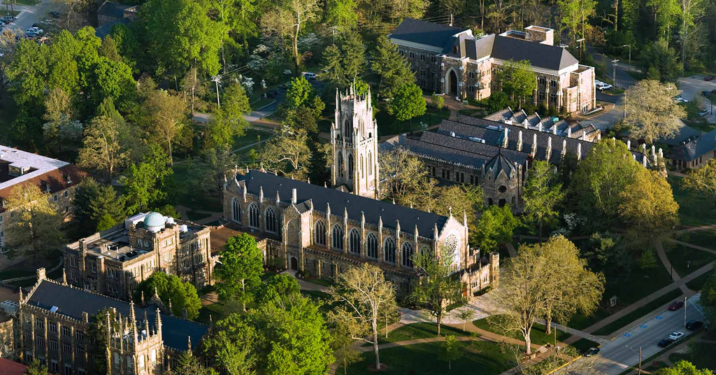

## Sewanee: “The Oxford of the South”

[figure not shown]

# A (brief) overview of decision modelling approaches

# Deterministic Models

### Cohort-level models that track expected values.

## Deterministic Models

1. Discrete Time Markov Cohort
- Characterized by transitions among mutually exclusive health states.
- Useful for expected outcomes, though possible to analytically solve for higher-order moments, e.g., variance, skewness; see Caswell and van Daalen (2021).

## Deterministic Models

2. Differential equations modelling
- Draws on stochastic process theory to represent systems using differential equations (DEQs).
- Solutions to DEQs provide occupancy of underlying process at time $t$.

# Stochastic Models

### Individual-level models that simulate patient pathways with random variation.

## Stochastic Models

1. Microsimulation
   - An individual state-transition model (STM).
   - Allows transition probabilities that are a function of attributes. (e.g., time since disease onset, the occurrence of previous events, or time-varying response to treatment).
   - Can capture greater scope of outputs since the model returns the distribution of events.

## Stochastic Models

2. Discrete Event Simulation
- Extends the flexibilities of microsimulation.
- Models time to event(s) explictly.
- Can incorporate interdependencies and resource contention (e.g., wait times, queues).

# A Taxonomy of Modelling Error

# Unavoidable (Shared) Errors

### *Definition*: Inherent errors you (generally) cannot minimize or sidestep by choosing a specific modelling approach.

## 1. Errors in Expectation

- Structural errors that result in bias.
- Attributes of models / parameters that result in model estimates that deviate from the “true” underlying event generation process.
- Not the same as heterogeneity!

## 1. Errors in Expectation

- Structural errors that result in bias..
- Attributes of models / parameters that result in model estimates that deviate from the “true” underlying event generation process.
- Not the same as heterogeneity!

Biases in outcomes due to unmodelled queues / resource contention can be addressed using DES!

## 1. Errors in Expectation

| Error Type | Deterministic Models DEQ | Deterministic Models MRKCHRT | Stochastic Models MICROSIM | Stochastic Models DES |
| --- | --- | --- | --- | --- |
| Structural | ✓ | ✓ | ✓ | ✓ |

## 2. Estimation Errors

- Sampling and estimation uncertainty.
- Focus of VOI.

## 2. Estimation Errors

| Error Type | Deterministic Models DEQ | Deterministic Models MRKCHRT | Stochastic Models MICROSIM | Stochastic Models DES |
| --- | --- | --- | --- | --- |
| Structural | ✓ | ✓ | ✓ | ✓ |
| Estimation and sampling | ✓ | ✓ | ✓ | ✓ |

# Addressable Errors

### *Definintion*: Errors you can address using specific methods and approaches.

Can minimize or sidestep by choosing a specific modelling approach.

## 3. Integration Error

- Occurs when events accumulate at cycle boundaries.
- Easily corrected with 1/2 cycle correction, Simpson’s rule approaches, etc.

## 3. Integration Error

| Error Type | Deterministic Models DEQ | Deterministic Models MRKCHRT | Stochastic Models MICROSIM | Stochastic Models DES |
| --- | --- | --- | --- | --- |
| Structural | ✓ | ✓ | ✓ | ✓ |
| Estimation and sampling | ✓ | ✓ | ✓ | ✓ |
| Integration |  | ✓ | ✓ |  |

## 4. Stochastic Error

- Realisation and timing of events among otherwise identical patients may vary.
- Literature refers to this as “first-order” uncertainty.
- Can be addressed by increasing simulated patient sample $M$.

## 4. Stochastic Error

| Error Type | Deterministic Models DEQ | Deterministic Models MRKCHRT | Stochastic Models MICROSIM | Stochastic Models DES |
| --- | --- | --- | --- | --- |
| Structural | ✓ | ✓ | ✓ | ✓ |
| Estimation and sampling | ✓ | ✓ | ✓ | ✓ |
| Integration |  | ✓ | ✓ |  |
| Stochastic |  |  | ✓ | ✓ |

## 5. Embedding Error

- Standard rate-to-probability conversion formulas (i.e., $P = 1 - e^{-rt}$) only accurate if no competing events.
- One-by-one conversions will effectively rule out the possibility of 2 or more events in same cycle.
- Easily addressed by embedding transition probability matrix $\mathbf{P}$ using matrix analogue to standard formula, i.e., $\mathbf{P} = \exp{(\mathbf{R}t})$.
- See Leech et al. (2025) and Graves et al. (2021) for techniques.

## 5. Embedding Error

| Error Type | Deterministic Models DEQ | Deterministic Models MRKCHRT | Stochastic Models MICROSIM | Stochastic Models DES |
| --- | --- | --- | --- | --- |
| Structural | ✓ | ✓ | ✓ | ✓ |
| Estimation and sampling | ✓ | ✓ | ✓ | ✓ |
| Integration |  | ✓ | ✓ |  |
| Stochastic |  |  | ✓ | ✓ |
| Embedding |  | ✓ | ✓ |  |

## 6. Truncation Error

- Information on the precise timing of an event occurring in continuous time is lost when event times are moved to the cycle boundary point.
- Analogue: loss of power when dichotomizing a continuous variable.

## Information Loss in Discrete Time

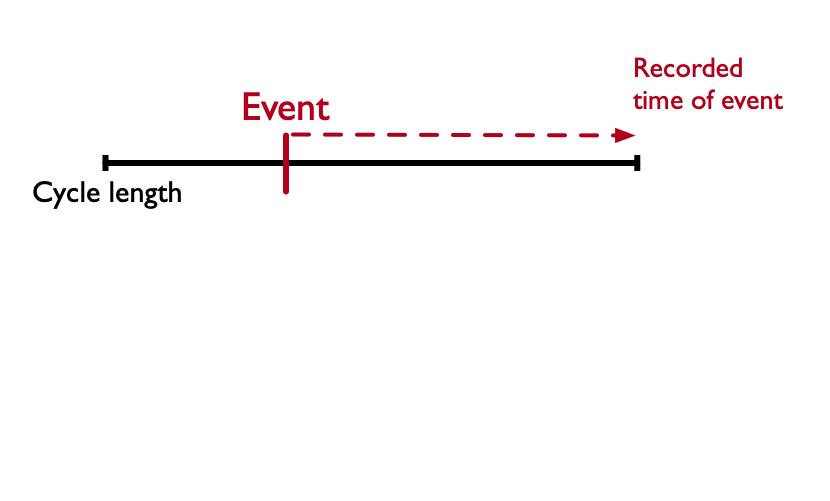

## Information Loss in Discrete Time

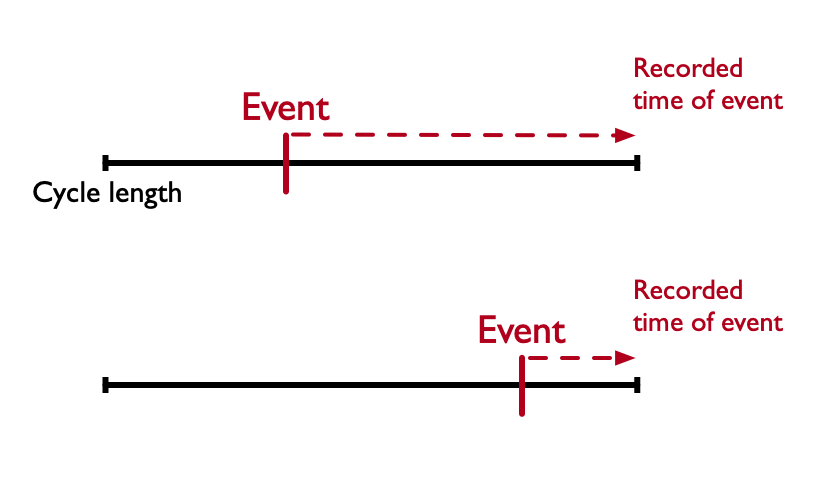

## Information Loss in Discrete Time

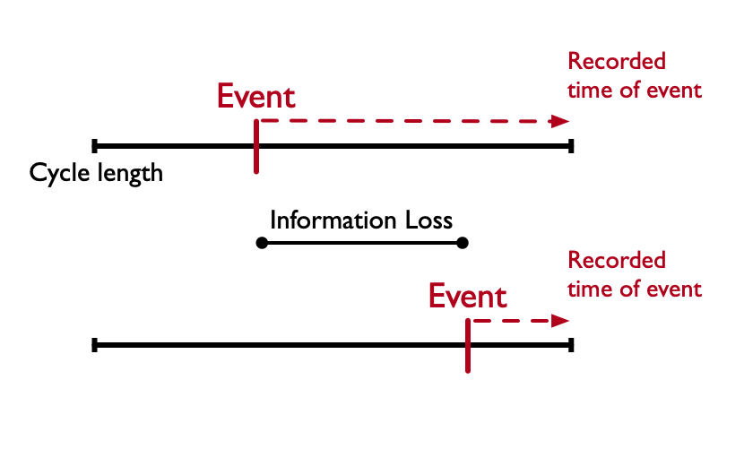

## Truncation Error vs. Integration Error

- **Integration error** affects expected values.
- **Truncation error** affects variance.
- Addressable by increasing simulated patient size $M$ or decreasing cycle length.

## Truncation Error

| Error Type | Deterministic Models DEQ | Deterministic Models MRKCHRT | Stochastic Models MICROSIM | Stochastic Models DES |
| --- | --- | --- | --- | --- |
| Structural | ✓ | ✓ | ✓ | ✓ |
| Estimation and sampling | ✓ | ✓ | ✓ | ✓ |
| Integration |  | ✓ | ✓ |  |
| Stochastic |  |  | ✓ | ✓ |
| Embedding |  | ✓ | ✓ |  |
| Truncation |  |  | ✓ |  |

# Why use DES?

## What Does DES Buy You?

- DES offers the same benefits as microsimulation but requires **considerably fewer** simulated patients.
- DES opens up new modelling strategies (e.g., based on patient queues, wait times, etc.) that are difficult/impossible in other modelling environments.

Source: Graves et al. (2021)

## What Does DES Buy You?

- **No embedding error** because event times are sampled based on rates.
- **No truncation error** because exact event times used.
- Consequently, DES **will converge much faster** than microsimulation.

Source: Graves et al. (2021)

## References

[figure not shown]

Caswell, Hal, and Silke van Daalen. 2021. “Healthy Longevity from Incidence-Based Models: More Kinds of Health Than Stars in the Sky.” *Demographic Research* 45 (July): 397–452. https://doi.org/10.4054/demres.2021.45.13.

Graves, John, Shawn Garbett, Zilu Zhou, Jonathan S Schildcrout, and Josh Peterson. 2021. “Comparison of Decision Modeling Approaches for Health Technology and Policy Evaluation.” *Medical Decision Making* 41 (4): 453–64.

Leech, Ashley A, Jinyi Zhu, Hannah Peterson, Marie H Martin, Grace Ratcliff, Shawn Garbett, and John A Graves. 2025. “Modeling Disability-Adjusted Life-Years for Policy and Decision Analysis.” *Medical Decision Making*, 0272989X251340077.